# Binary Classification Model for [Project Name] Using R version 09

### 3.b) Feature Selection

```r
# Not applicable for this iteration of the project
# Using the correlations calculated previously, we try to find attributes that are highly correlated.
# highlyCorrelated <- findCorrelation(correlations, cutoff=0.85)
# print(highlyCorrelated)
# cat('Number of attributes found to be highly correlated:',length(highlyCorrelated))

# Removing the highly correlated attributes from the training and validation dataframes
# xy_train <- xy_train[, -highlyCorrelated]
# xy_test <- xy_test[, -highlyCorrelated]
```

```r
# Not applicable for this iteration of the project
# Sample code for performing feature selection by ranking the attributes' importance.
# startTimeModule <- proc.time()
# set.seed(seedNum)
# library(gbm)
# model_fs <- train(targetVar~., data=xy_train, method="gbm", preProcess="scale", trControl=control, verbose=F)
# rankedImportance <- varImp(model_fs, scale=FALSE)
# print(rankedImportance)
# plot(rankedImportance)

# Set the importance threshold and calculate the list of attributes that don't contribute to the importance threshold
# maxThreshold <- 0.99
# rankedAttributes <- rankedImportance$importance
# rankedAttributes <- rankedAttributes[order(-rankedAttributes$Overall),,drop=FALSE]
# totalWeight <- sum(rankedAttributes)
# i <- 1
# accumWeight <- 0
# exit_now <- FALSE
# while ((i <= totAttr) & !exit_now) {
#   accumWeight = accumWeight + rankedAttributes[i,]
#   if ((accumWeight/totalWeight) >= maxThreshold) {
#     exit_now <- TRUE
#   } else {
#     i <- i + 1
#   }
# }
# lowImportance <- rankedAttributes[(i+1):(totAttr),,drop=FALSE]
# lowAttributes <- rownames(lowImportance)
# cat('Number of attributes contributed to the importance threshold:',i,"\n")
# cat('Number of attributes found to be of low importance:',length(lowAttributes))

# Removing the unselected attributes from the training and validation dataframes
# xy_train <- xy_train[, !(names(xy_train) %in% lowAttributes)]
# xy_test <- xy_test[, !(names(xy_test) %in% lowAttributes)]
```

```r
# Not applicable for this iteration of the project
# Sample code for perfoming feature selection using the Recursive Feature Elimination (RFE) technique
# startTimeModule <- proc.time()
# set.seed(seedNum)
# rfeCTRL <- rfeControl(functions=rfFuncs, method="cv", number=10)
# rfeResults <- rfe(xy_train[,1:totAttr], xy_train[,totCol], sizes=c(30:55), rfeControl=rfeCTRL)
# print(rfeResults)
# rfeAttributes <- predictors(rfeResults)
# cat('Number of attributes identified from the RFE algorithm:',length(rfeAttributes))
# print(rfeAttributes)
# plot(rfeResults, type=c("g", "o"))

# Removing the unselected attributes from the training and validation dataframes
# rfeAttributes <- c(rfeAttributes,"targetVar")
# xy_train <- xy_train[, (names(xy_train) %in% rfeAttributes)]
# xy_test <- xy_test[, (names(xy_test) %in% rfeAttributes)]
```

### 3.c) Data Transforms

```r
# Not applicable for this iteration of the project
# Sample code for performing SMOTE transformation to combat the unbalanced data
# set.seed(seedNum)
# xy_train <- SMOTE(targetVar ~., data=xy_train, perc.over=200, perc.under=300)
# totCol <- ncol(xy_train)
# y_train <- xy_train[,totCol]
# cbind(freq=table(y_train), percentage=prop.table(table(y_train))*100)
```

### 3.d) Display the Final Dataset for Model-Building

```r
dim(xy_train)
```

```
## [1] 146  61
```

```r
dim(xy_test)
```

```
## [1] 62 61
```

```r
sapply(xy_train, class)
```

```
##     attr1     attr2     attr3     attr4     attr5     attr6     attr7
## "numeric" "numeric" "numeric" "numeric" "numeric" "numeric" "numeric"
##     attr8     attr9    attr10    attr11    attr12    attr13    attr14
## "numeric" "numeric" "numeric" "numeric" "numeric" "numeric" "numeric"
##    attr15    attr16    attr17    attr18    attr19    attr20    attr21
## "numeric" "numeric" "numeric" "numeric" "numeric" "numeric" "numeric"
##    attr22    attr23    attr24    attr25    attr26    attr27    attr28
## "numeric" "numeric" "numeric" "numeric" "numeric" "numeric" "numeric"
##    attr29    attr30    attr31    attr32    attr33    attr34    attr35
## "numeric" "numeric" "numeric" "numeric" "numeric" "numeric" "numeric"
##    attr36    attr37    attr38    attr39    attr40    attr41    attr42
## "numeric" "numeric" "numeric" "numeric" "numeric" "numeric" "numeric"
##    attr43    attr44    attr45    attr46    attr47    attr48    attr49
## "numeric" "numeric" "numeric" "numeric" "numeric" "numeric" "numeric"
##    attr50    attr51    attr52    attr53    attr54    attr55    attr56
## "numeric" "numeric" "numeric" "numeric" "numeric" "numeric" "numeric"
##    attr57    attr58    attr59    attr60 targetVar
## "numeric" "numeric" "numeric" "numeric"  "factor"
```

```r
email_notify(paste("Data Cleaning and Transformation completed!",date()))
```

```
## [1] "Java-Object{org.apache.commons.mail.SimpleEmail@63753b6d}"
```

```r
proc.time()-startTimeScript
```

```
##    user  system elapsed
##   25.72    8.74   48.55
```

## 4. Model and Evaluate Algorithms

After the data-prep, we next work on finding a workable model by evaluating a subset of machine learning algorithms that are good at exploiting the structure of the training. The typical evaluation tasks include:

- Defining test options such as cross validation and the evaluation metric to use.
- Spot checking a suite of linear and nonlinear machine learning algorithms.
- Comparing the estimated accuracy of algorithms.

For this project, we will evaluate one linear, two non-linear, and three ensemble algorithms:

Linear Algorithm: Logistic Regression

Non-Linear Algorithms: Decision Trees (CART) and k-Nearest Neighbors

Ensemble Algorithms: Bagged CART, Random Forest, and Gradient Boosting

The random number seed is reset before each run to ensure that the evaluation of each algorithm is performed using the same data splits. It ensures the results are directly comparable.

### 4.a) Generate models using linear algorithms

```r
# Logistic Regression (Classification)
email_notify(paste("Linear Regression modeling has begun!",date()))
```

```
## [1] "Java-Object{org.apache.commons.mail.SimpleEmail@6c3708b3}"
```

```r
startTimeModule <- proc.time()
set.seed(seedNum)
fit.glm <- train(targetVar~., data=xy_train, method="glm", metric=metricTarget, trControl=control)
print(fit.glm)
```

```
## Generalized Linear Model
##
## 146 samples
##  60 predictor
##   2 classes: 'M', 'R'
##
## No pre-processing
## Resampling: Cross-Validated (10 fold, repeated 3 times)
## Summary of sample sizes: 131, 132, 131, 131, 131, 131, ...
## Resampling results:
##
##   Accuracy   Kappa
##   0.7009524  0.4002481
```

```r
proc.time()-startTimeModule
```

```
##    user  system elapsed
##    2.55    0.03    4.09
```

```r
email_notify(paste("Linear Regression modeling completed!",date()))
```

```
## [1] "Java-Object{org.apache.commons.mail.SimpleEmail@57536d79}"
```

### 4.b) Generate models using nonlinear algorithms

```r
# Decision Tree - CART (Regression/Classification)
email_notify(paste("Decision Tree modeling has begun!",date()))
```

```
## [1] "Java-Object{org.apache.commons.mail.SimpleEmail@1f28c152}"
```

```r
startTimeModule <- proc.time()
set.seed(seedNum)
fit.cart <- train(targetVar~., data=xy_train, method="rpart", metric=metricTarget, trControl=control)
print(fit.cart)
```

```
## CART
##
## 146 samples
##  60 predictor
##   2 classes: 'M', 'R'
##
## No pre-processing
## Resampling: Cross-Validated (10 fold, repeated 3 times)
## Summary of sample sizes: 131, 132, 131, 131, 131, 131, ...
## Resampling results across tuning parameters:
##
##   cp          Accuracy   Kappa
##   0.02941176  0.7806349  0.5579983
##   0.08823529  0.7511111  0.4978626
##   0.51470588  0.6444444  0.2524722
##
## Accuracy was used to select the optimal model using the largest value.
## The final value used for the model was cp = 0.02941176.
```

```r
proc.time()-startTimeModule
```

```
##    user  system elapsed
##    2.80    0.02    4.53
```

```r
email_notify(paste("Decision Tree modeling completed!",date()))
```

```
## [1] "Java-Object{org.apache.commons.mail.SimpleEmail@67b92f0a}"
```

```r
# k-Nearest Neighbors (Regression/Classification)
email_notify(paste("k-Nearest Neighbors modeling has begun!",date()))
```

```
## [1] "Java-Object{org.apache.commons.mail.SimpleEmail@887af79}"
```

```r
startTimeModule <- proc.time()
set.seed(seedNum)
fit.knn <- train(targetVar~., data=xy_train, method="knn", metric=metricTarget, trControl=control)
print(fit.knn)
```

```
## k-Nearest Neighbors
##
## 146 samples
##  60 predictor
##   2 classes: 'M', 'R'
##
## No pre-processing
## Resampling: Cross-Validated (10 fold, repeated 3 times)
## Summary of sample sizes: 131, 132, 131, 131, 131, 131, ...
## Resampling results across tuning parameters:
##
##   k  Accuracy   Kappa
##   5  0.7212698  0.4337346
##   7  0.6807937  0.3494029
##   9  0.6515873  0.2874133
##
## Accuracy was used to select the optimal model using the largest value.
## The final value used for the model was k = 5.
```

```r
proc.time()-startTimeModule
```

```
##    user  system elapsed
##    1.51    0.03    2.08
```

```r
email_notify(paste("k-Nearest Neighbors modeling completed!",date()))
```

```
## [1] "Java-Object{org.apache.commons.mail.SimpleEmail@23e028a9}"
```

### 4.c) Generate models using ensemble algorithms

In this section, we will explore the use and tuning of ensemble algorithms to see whether we can improve the results.

```r
# Bagged CART (Regression/Classification)
email_notify(paste("Bagged CART modeling has begun!",date()))
```

```
## [1] "Java-Object{org.apache.commons.mail.SimpleEmail@3701eaf6}"
```

```r
startTimeModule <- proc.time()
set.seed(seedNum)
fit.bagcart <- train(targetVar~., data=xy_train, method="treebag", metric=metricTarget, trControl=control)
print(fit.bagcart)
```

```
## Bagged CART
##
## 146 samples
##  60 predictor
##   2 classes: 'M', 'R'
##
## No pre-processing
## Resampling: Cross-Validated (10 fold, repeated 3 times)
## Summary of sample sizes: 131, 132, 131, 131, 131, 131, ...
## Resampling results:
##
##   Accuracy   Kappa
##   0.7853968  0.5641831
```

```r
proc.time()-startTimeModule
```

```
##    user  system elapsed
##   13.56    0.09   15.17
```

```r
email_notify(paste("Bagged CART modeling completed!",date()))
```

```
## [1] "Java-Object{org.apache.commons.mail.SimpleEmail@551aa95a}"
```

```r
# Random Forest (Regression/Classification)
email_notify(paste("Random Forest modeling has begun!",date()))
```

```
## [1] "Java-Object{org.apache.commons.mail.SimpleEmail@3cef309d}"
```

```r
startTimeModule <- proc.time()
set.seed(seedNum)
fit.rf <- train(targetVar~., data=xy_train, method="rf", metric=metricTarget, trControl=control)
print(fit.rf)
```

```
## Random Forest
##
## 146 samples
##  60 predictor
##   2 classes: 'M', 'R'
##
## No pre-processing
## Resampling: Cross-Validated (10 fold, repeated 3 times)
## Summary of sample sizes: 131, 132, 131, 131, 131, 131, ...
## Resampling results across tuning parameters:
##
##   mtry  Accuracy   Kappa
##    2    0.8069841  0.6079932
##   31    0.8106349  0.6147568
##   60    0.8039683  0.6001316
##
## Accuracy was used to select the optimal model using the largest value.
## The final value used for the model was mtry = 31.
```

```r
proc.time()-startTimeModule
```

```
##    user  system elapsed
##   21.34    0.23   22.81
```

```r
email_notify(paste("Random Forest modeling completed!",date()))
```

```
## [1] "Java-Object{org.apache.commons.mail.SimpleEmail@7494e528}"
```

```r
# Gradient Boosting (Regression/Classification)
email_notify(paste("Gradient Boosting modeling has begun!",date()))
```

```
## [1] "Java-Object{org.apache.commons.mail.SimpleEmail@5e853265}"
```

```r
startTimeModule <- proc.time()
set.seed(seedNum)
fit.gbm <- train(targetVar~., data=xy_train, method="xgbTree", metric=metricTarget, trControl=control, verbose=F)
# fit.gbm <- train(targetVar~., data=xy_train, method="gbm", metric=metricTarget, trControl=control, verbose=F)
print(fit.gbm)
```

```
## eXtreme Gradient Boosting
##
## 146 samples
##  60 predictor
##   2 classes: 'M', 'R'
##
## No pre-processing
## Resampling: Cross-Validated (10 fold, repeated 3 times)
## Summary of sample sizes: 131, 132, 131, 131, 131, 131, ...
## Resampling results across tuning parameters:
##
##   eta  max_depth  colsample_bytree  subsample  nrounds  Accuracy
##   0.3  1          0.6               0.50        50      0.8012698
##   0.3  1          0.6               0.50       100      0.7923810
##   0.3  1          0.6               0.50       150      0.7830159
##   0.3  1          0.6               0.75        50      0.8003175
##   0.3  1          0.6               0.75       100      0.8193651
##   0.3  1          0.6               0.75       150      0.8128571
##   0.3  1          0.6               1.00        50      0.8169841
##   0.3  1          0.6               1.00       100      0.8195238
##   0.3  1          0.6               1.00       150      0.8217460
##   0.3  1          0.8               0.50        50      0.7812698
##   0.3  1          0.8               0.50       100      0.7849206
##   0.3  1          0.8               0.50       150      0.7895238
##   0.3  1          0.8               0.75        50      0.8263492
##   0.3  1          0.8               0.75       100      0.8190476
##   0.3  1          0.8               0.75       150      0.8123810
##   0.3  1          0.8               1.00        50      0.8103175
##   0.3  1          0.8               1.00       100      0.8149206
##   0.3  1          0.8               1.00       150      0.8126984
##   0.3  2          0.6               0.50        50      0.8033333
##   0.3  2          0.6               0.50       100      0.7969841
##   0.3  2          0.6               0.50       150      0.7923810
##   0.3  2          0.6               0.75        50      0.7930159
##   0.3  2          0.6               0.75       100      0.7976190
##   0.3  2          0.6               0.75       150      0.7953968
##   0.3  2          0.6               1.00        50      0.8109524
##   0.3  2          0.6               1.00       100      0.8204762
##   0.3  2          0.6               1.00       150      0.8157143
##   0.3  2          0.8               0.50        50      0.7844444
```

[output cut: 182 more lines]

```
##   0.5948061
##   0.5845729
##   0.5928459
##   0.5835983
##   0.6090043
##   0.6042191
##   0.6181488
##
## Tuning parameter 'gamma' was held constant at a value of 0
##
## Tuning parameter 'min_child_weight' was held constant at a value of 1
## Accuracy was used to select the optimal model using the largest value.
## The final values used for the model were nrounds = 50, max_depth = 1,
##  eta = 0.3, gamma = 0, colsample_bytree = 0.8, min_child_weight = 1
##  and subsample = 0.75.
```

```r
proc.time()-startTimeModule
```

```
##    user  system elapsed
##  283.10  145.34  279.11
```

```r
email_notify(paste("Gradient Boosting modeling completed!",date()))
```

```
## [1] "Java-Object{org.apache.commons.mail.SimpleEmail@131276c2}"
```

### 4.d) Compare baseline algorithms

```r
results <- resamples(list(LR=fit.glm, CART=fit.cart, kNN=fit.knn, BagCART=fit.bagcart, RF=fit.rf, GBM=fit.gbm))
summary(results)
```

```
##
## Call:
## summary.resamples(object = results)
##
## Models: LR, CART, kNN, BagCART, RF, GBM
## Number of resamples: 30
##
## Accuracy
##              Min.   1st Qu.    Median      Mean   3rd Qu.      Max. NA's
## LR      0.5000000 0.6107143 0.7142857 0.7009524 0.7857143 0.9333333    0
## CART    0.5000000 0.7190476 0.7928571 0.7806349 0.8571429 1.0000000    0
## kNN     0.4666667 0.6107143 0.7333333 0.7212698 0.8428571 0.9333333    0
## BagCART 0.6000000 0.7142857 0.7595238 0.7853968 0.8642857 1.0000000    0
## RF      0.6428571 0.7464286 0.8000000 0.8106349 0.8666667 1.0000000    0
## GBM     0.5714286 0.7857143 0.8571429 0.8263492 0.8666667 1.0000000    0
##
## Kappa
##                Min.   1st Qu.    Median      Mean   3rd Qu.      Max. NA's
## LR       0.00000000 0.2187500 0.4285714 0.4002481 0.5668693 0.8672566    0
## CART     0.00000000 0.4375000 0.5830116 0.5579983 0.7083333 1.0000000    0
## kNN     -0.07142857 0.2293233 0.4545455 0.4337346 0.6703878 0.8648649    0
## BagCART  0.16666667 0.4285714 0.5087386 0.5641831 0.7276786 1.0000000    0
## RF       0.28571429 0.4865122 0.6017699 0.6147568 0.7309253 1.0000000    0
## GBM      0.14285714 0.5577508 0.7083333 0.6484095 0.7368421 1.0000000    0
```

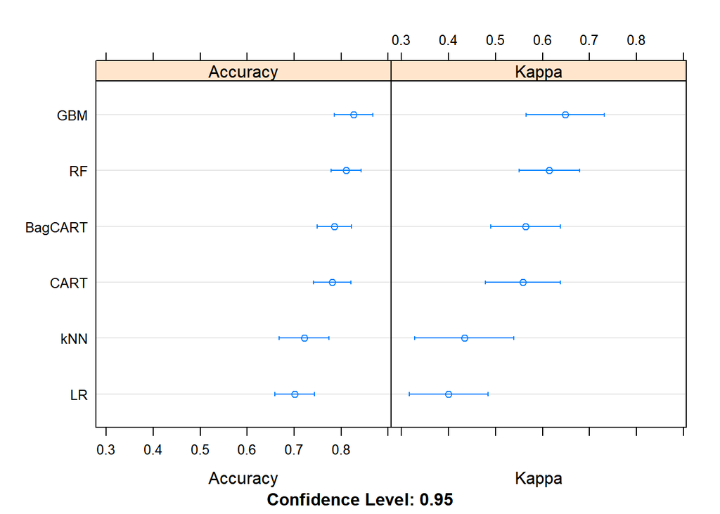

```r
dotplot(results)
```

```r
cat('The average accuracy from all models is:',
    mean(c(results$values$`LR~Accuracy`,results$values$`CART~Accuracy`,results$values$`kNN~Accuracy`,results$values$`BagCART~Accuracy`,results$values$`RF~Accuracy`,results$values$`GBM~Accuracy`)))
```

```
## The average accuracy from all models is: 0.770873
```

## 5. Improve Accuracy or Results

After we achieve a short list of machine learning algorithms with good level of accuracy, we can leverage ways to improve the accuracy of the models.

### 5.a) Algorithm Tuning

```r
# Tuning algorithm #1 - Random Forest
email_notify(paste("Algorithm #1 tuning has begun!",date()))
```

```
## [1] "Java-Object{org.apache.commons.mail.SimpleEmail@51cdd8a}"
```

```r
startTimeModule <- proc.time()
set.seed(seedNum)
grid <- expand.grid(mtry=c(2,15,30,45,60))
fit.final1 <- train(targetVar~., data=xy_train, method="rf", metric=metricTarget, trControl=control)
print(fit.final1)
```

```
## Random Forest
##
## 146 samples
##  60 predictor
##   2 classes: 'M', 'R'
##
## No pre-processing
## Resampling: Cross-Validated (10 fold, repeated 3 times)
## Summary of sample sizes: 131, 132, 131, 131, 131, 131, ...
## Resampling results across tuning parameters:
##
##   mtry  Accuracy   Kappa
##    2    0.8069841  0.6079932
##   31    0.8106349  0.6147568
##   60    0.8039683  0.6001316
##
## Accuracy was used to select the optimal model using the largest value.
## The final value used for the model was mtry = 31.
```

```r
proc.time()-startTimeModule
```

```
##    user  system elapsed
##   15.95    0.16   16.30
```

```r
email_notify(paste("Algorithm #1 tuning completed!",date()))
```

```
## [1] "Java-Object{org.apache.commons.mail.SimpleEmail@10bbd20a}"
```

```r
# Tuning algorithm #2 - Gradient Boosting
email_notify(paste("Algorithm #2 tuning has begun!",date()))
```

```
## [1] "Java-Object{org.apache.commons.mail.SimpleEmail@5a1c0542}"
```

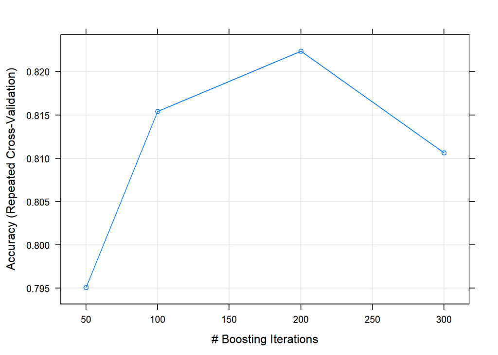

```r
startTimeModule <- proc.time()
set.seed(seedNum)
grid <- expand.grid(nrounds=c(50,100,200,300), max_depth=1, eta=0.3, gamma=0, colsample_bytree=0.8, min_child_weight=1, subsample=0.75)
fit.final2 <- train(targetVar~., data=xy_train, method="xgbTree", metric=metricTarget, tuneGrid=grid, trControl=control, verbose=F)
plot(fit.final2)
```

```r
print(fit.final2)
```

[output not shown]

```r
proc.time()-startTimeModule
```

```
##    user  system elapsed
##   12.00    5.75   11.53
```

```r
email_notify(paste("Algorithm #2 tuning completed!",date()))
```

```
## [1] "Java-Object{org.apache.commons.mail.SimpleEmail@167fdd33}"
```

### 5.d) Compare Algorithms After Tuning

```r
results <- resamples(list(RF=fit.final1, GBM=fit.final2))
summary(results)
```

```
##
## Call:
## summary.resamples(object = results)
##
## Models: RF, GBM
## Number of resamples: 30
##
## Accuracy
##          Min.   1st Qu.    Median      Mean   3rd Qu. Max. NA's
## RF  0.6428571 0.7464286 0.8000000 0.8106349 0.8666667    1    0
## GBM 0.5333333 0.7892857 0.8571429 0.8223810 0.8666667    1    0
##
## Kappa
##           Min.   1st Qu.    Median      Mean   3rd Qu. Max. NA's
## RF  0.28571429 0.4865122 0.6017699 0.6147568 0.7309253    1    0
## GBM 0.03669725 0.5753604 0.6956522 0.6409014 0.7309253    1    0
```

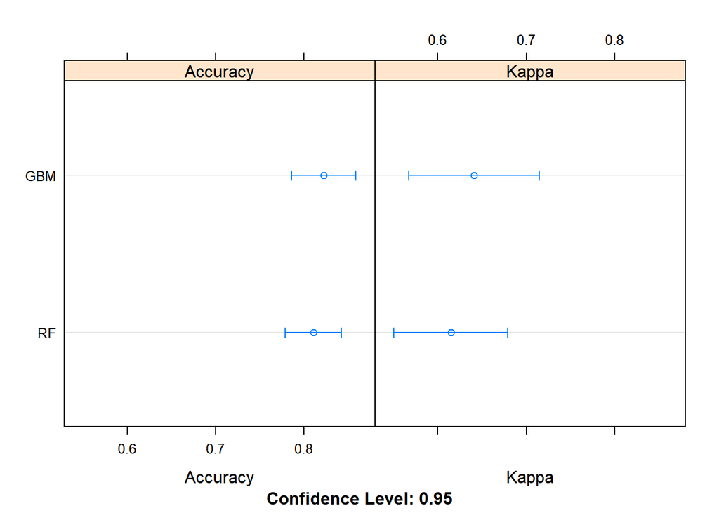

```r
dotplot(results)
```

## 6. Finalize Model and Present Results

Once we have narrow down to a model that we believe can make accurate predictions on unseen data, we are ready to finalize it. Finalizing a model may involve sub-tasks such as:

- Using an optimal model tuned to make predictions on unseen data.
- Creating a standalone model using the tuned parameters
- Saving an optimal model to file for later use.

```r
email_notify(paste("Model Validation and Final Model Creation has begun!",date()))
```

```
## [1] "Java-Object{org.apache.commons.mail.SimpleEmail@74650e52}"
```

### 6.a) Predictions on validation dataset

```r
predictions <- predict(fit.final2, newdata=xy_test)
confusionMatrix(predictions, y_test)
```

```
## Confusion Matrix and Statistics
##
##           Reference
## Prediction  M  R
##          M 28  2
##          R  5 27
##
##                Accuracy : 0.8871
##                  95% CI : (0.7811, 0.9534)
##     No Information Rate : 0.5323
##     P-Value [Acc > NIR] : 2.418e-09
##
##                   Kappa : 0.7747
##
##  Mcnemar's Test P-Value : 0.4497
##
##             Sensitivity : 0.8485
##             Specificity : 0.9310
##          Pos Pred Value : 0.9333
##          Neg Pred Value : 0.8438
##              Prevalence : 0.5323
##          Detection Rate : 0.4516
##    Detection Prevalence : 0.4839
##       Balanced Accuracy : 0.8898
##
##        'Positive' Class : M
##
```

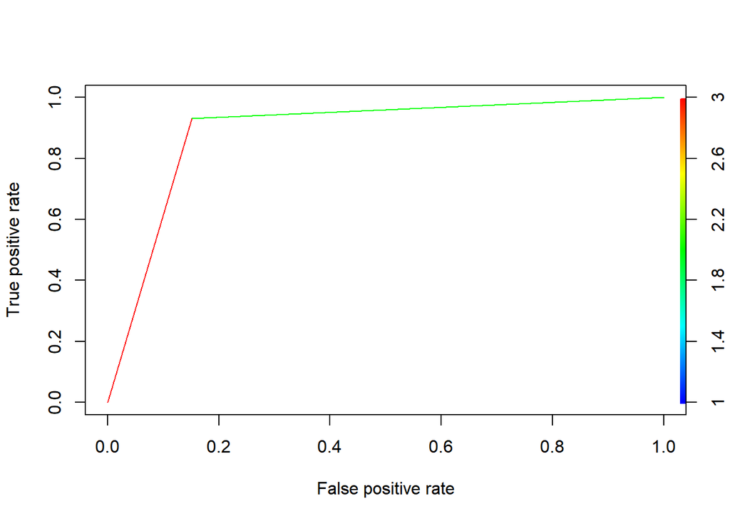

```r
pred <- prediction(as.numeric(predictions), as.numeric(y_test))
perf <- performance(pred, measure = "tpr", x.measure = "fpr")
plot(perf, colorize=TRUE)
```

```r
auc <- performance(pred, measure = "auc")
auc <- auc@y.values[[1]]
auc
```

```
## [1] 0.8897597
```

### 6.b) Create standalone model on entire training dataset

```r
startTimeModule <- proc.time()
library(xgboost)
set.seed(seedNum)

# Combining the training and test datasets to form the original dataset that will be used for training the final model
xy_complete <- rbind(xy_train, xy_test)
y_final <- xy_complete$targetVar
xy_complete$targetVar <- NULL
x_final <- as.matrix(xy_complete)

finalModel <- xgboost(data=x_final, label=y_final, nrounds=200, max_depth=1, eta=0.3, gamma=0, colsample_bytree=0.8, min_child_weight=1, subsample=0.75)
print(finalModel)
```

```
## ##### xgb.Booster
## raw: 51.2 Kb
## call:
##   xgb.train(params = params, data = dtrain, nrounds = nrounds,
##     watchlist = watchlist, verbose = verbose, print_every_n = print_every_n,
##     early_stopping_rounds = early_stopping_rounds, maximize = maximize,
##     save_period = save_period, save_name = save_name, xgb_model = xgb_model,
##     callbacks = callbacks, max_depth = 1, eta = 0.3, gamma = 0,
##     colsample_bytree = 0.8, min_child_weight = 1, subsample = 0.75)
## params (as set within xgb.train):
##   max_depth = "1", eta = "0.3", gamma = "0", colsample_bytree = "0.8", min_child_weight = "1", subsample = "0.75", silent = "1"
## xgb.attributes:
##   niter
## callbacks:
##   cb.print.evaluation(period = print_every_n)
##   cb.evaluation.log()
## # of features: 60
## niter: 200
## nfeatures : 60
## evaluation_log:
##     iter train_rmse
##        1   0.823088
##        2   0.656240
## ---
##      199   0.098031
##      200   0.097387
```

```r
proc.time()-startTimeModule
```

```
##    user  system elapsed
##    0.44    0.16    0.39
```

### 6.c) Save model for later use

```r
#saveRDS(finalModel, "./finalModel_BinaryClass.rds")
```

```r
email_notify(paste("Model Validation and Final Model Creation Completed!",date()))
```

```
## [1] "Java-Object{org.apache.commons.mail.SimpleEmail@3712b94}"
```

```r
proc.time()-startTimeScript
```

```
##    user  system elapsed
##  384.53  161.02  437.27
```